# Project - Time Series

Ngan Pham

### The monthly median home price (in dollars, not adjusted for inflation) in the United States from January 1963 to September 2019.

```r
med.home.vec<-c(17200,17700,18200,18200,17500,18000,18400,17800,17900,17600,18400,18700,
17800,18000,19000,18800,19300,18800,19100,18900,18900,18900,19300,21000,
20700,20400,19800,19900,19600,19800,21000,20200,19600,19900,20600,20300,
21200,20900,20800,23000,22300,21200,21800,20700,22200,20800,21700,21700,
22200,22400,22400,22300,23700,23900,23300,21700,22800,22300,23100,22200,
23400,23500,24600,24500,25300,25400,24600,25000,25000,25600,24600,26500,
24600,26000,26200,25900,26900,25200,26800,24900,26000,24400,24900,25100,
23600,24100,24100,24200,25700,23800,22900,23500,22600,22100,23500,22300,
23900,24500,24300,25800,25500,26100,25200,25300,25400,25600,25700,25300,
24700,26500,27400,26700,27000,26800,27700,28100,28000,28900,29100,29700,
29900,29700,31400,32800,32000,33100,34200,33200,33200,33300,34000,35700,
34200,34900,36000,35700,35700,35100,36800,35700,36200,37200,37300,37400,
37200,37900,38800,39200,39500,37900,38600,38200,39700,40700,41100,42100,
41600,42700,43600,43300,43600,46100,44600,44200,44700,45300,45800,45900,
45500,47400,46200,48700,49300,48700,48600,49000,48500,51400,51800,52700,
52300,53200,53200,53300,55700,56700,54800,56100,57300,58300,58700,59900,
60300,61200,60400,62600,62800,64200,63800,64000,66000,62300,63900,61500,
62900,64900,62600,63100,63100,64900,64000,63400,68300,65600,66700,67000,
67600,66200,66700,68700,70800,68800,69500,72600,65800,69600,71200,68400,
66200,65700,67200,70200,69300,69300,70900,70100,67800,69700,73500,71700,
73500,73800,72500,74700,74500,75800,75200,76800,81000,75900,75900,75900,
76200,79200,78400,79600,81400,80500,80700,82000,81300,80100,82500,78300,
82500,82000,84200,85600,80100,86300,82100,83300,84700,85400,87200,87900,
86600,89700,88700,92500,92100,91200,94100,91500,95000,96400,94000,95000,
98500,95200,98400,96500,104900,109000,105000,106800,106500,106500,117000,111800,
119000,110900,108900,111000,110000,111500,118000,110000,116600,112900,110400,121000,
113000,118000,123000,116700,119000,122800,116000,122900,120000,123000,125000,125200,
125000,126900,119400,130000,125000,125000,118700,118400,113000,120000,118900,127000,
117900,119900,122500,121000,116000,119000,120000,120800,120000,122600,118500,122000,
120000,117200,120000,120000,113000,124500,118000,123500,119500,125000,128900,126000,
118000,129400,125000,127000,129900,124500,123900,126600,129400,125000,130000,125000,
126000,129900,132300,129000,129900,133500,124400,133300,129700,132000,129900,135000,
127900,135000,130000,134000,133900,133700,131000,134900,130000,135200,137000,138600,
131900,139400,137000,140000,136500,140000,144200,137000,139000,143800,143500,144900,
145000,143000,148000,150000,141000,145000,145900,144000,146300,141500,145000,145900,
148000,156000,152700,148000,153200,148000,149900,154900,155000,154500,151000,152500,
153100,160000,157300,159900,154400,159300,158200,154800,163200,161100,172000,164800,
163500,162400,165100,162600,164700,160100,169000,166600,171500,176300,174700,162000,
171300,169100,166300,175200,175300,179400,175000,173700,166400,171300,168100,180200,
187100,191100,183400,187100,181000,190600,175600,178900,177500,189200,181200,197600,
181700,187000,185100,189500,195500,187900,190200,190500,192000,194100,207100,196000,
209500,219600,209600,222300,211700,215700,212400,218100,211600,229200,224500,229600,
223100,237300,229300,236300,228300,226100,229200,240100,240400,243900,237900,238600,
244900,250800,238800,257000,238200,243200,238100,243900,226700,250400,240100,244700,
254400,250800,262600,242500,245000,235500,246200,236500,240300,234300,249100,227700,
232400,245300,229300,246400,229300,234300,237300,221000,225200,213200,221600,229600,
208600,209700,205100,219200,222300,214700,214200,207100,216600,215100,218800,222600,
218200,221900,224800,208300,230500,219500,212100,226600,228000,204200,219600,241200,
240100,220100,220500,224700,222000,240200,229900,219600,217000,224800,214300,218600,
221700,239900,239800,236400,239200,232600,237400,253200,254600,247200,245000,258300,
251500,265100,257500,279300,263700,259800,262200,255300,269800,264300,277100,275500,
269800,268400,282300,274500,285600,287000,280400,291700,261500,297000,298300,301500,
292000,286600,286600,294500,287500,285100,292300,293000,299500,298000,312600,297100,
288400,305800,303200,318300,295200,311200,297400,298900,314800,302800,315000,327000,
315200,298000,321700,311100,323600,315200,322900,314200,331500,319500,343400,343300,
329600,327200,335400,314400,316700,310500,327500,321400,328300,328300,308500,329700,
305400,320800,310600,339000,312700,311800,307600,325200,299400)

med.home.ts<-ts(med.home.vec,start=c(1963,1),frequency=12)
```

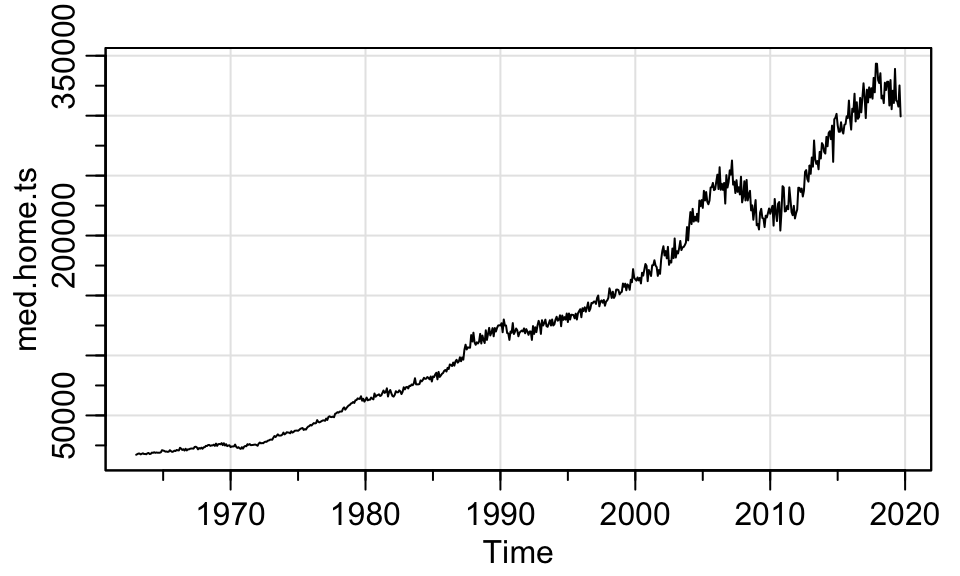

```r
tsplot(med.home.ts)
```

This data looks clearly nonstationary with non-constant mean and variance. It recorded a long prediod of time so it is hard to see trend of the data. We take a look at some short periods of time as following:

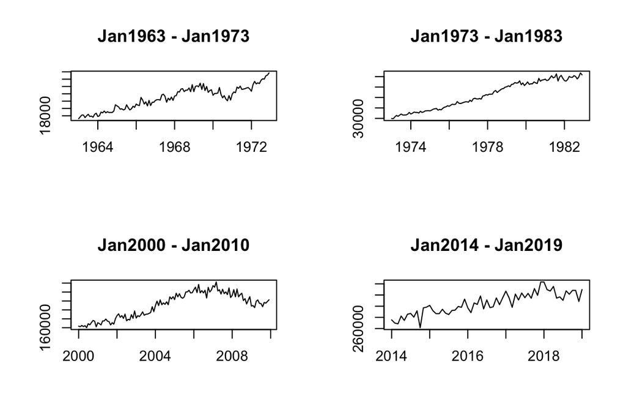

```r
par(mfrow=c(2,2))
plot(ts(med.home.vec[1:120],start=c(1963,1),frequency=12), main='Jan1963 - Jan1973',ylab=NULL,xlab=NULL)
plot(ts(med.home.vec[121:240],start=c(1973,1),frequency=12), main='Jan1973 - Jan1983',ylab=NULL,xlab=NULL)
plot(ts(med.home.vec[445:564],start=c(2000,1),frequency=12), main='Jan2000 - Jan2010',ylab=NULL,xlab=NULL)
plot(ts(med.home.vec[612:672],start=c(2014,1),frequency=12), main='Jan2014 - Jan2019',ylab=NULL,xlab=NULL)
```

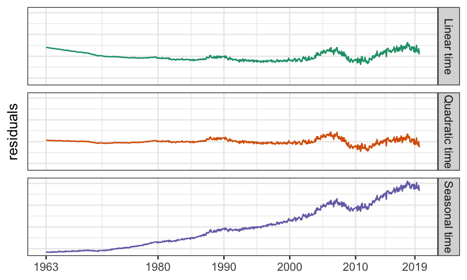

```r
df <- data.frame(residuals=c(residuals(lm(med.home.ts ~ time(med.home.ts))),
  residuals(lm(med.home.ts ~ time(med.home.ts) + I(time(med.home.ts)^2))),
  residuals(lm(med.home.ts ~ season(med.home.ts)-1))),
  model=c(rep('Linear time',681),
          rep('Quadratic time',681),
          rep('Seasonal time',681)))
ggplot(df, aes(x=rep(time(med.home.ts),3), y=residuals, color=model)) +
  geom_line() +
  facet_grid(model ~ .) +
  theme_bw() +
  theme(axis.text.y = element_blank(), axis.ticks.y = element_blank(),
        axis.title.x = element_blank(),legend.position = "none") +
  scale_x_continuous(breaks=c(1963,1980,1990,2000,2010,2019)) +
  scale_color_brewer(palette = 'Dark2')
```

All three models do not have stationary residuals. Another way to detrend the time series is to take differencing. In the following plots, the first differencing series has approximately constant mean but increasing variance, making it be a nonstationary time series. The log-transformed data also is nonstationary with the same reason.

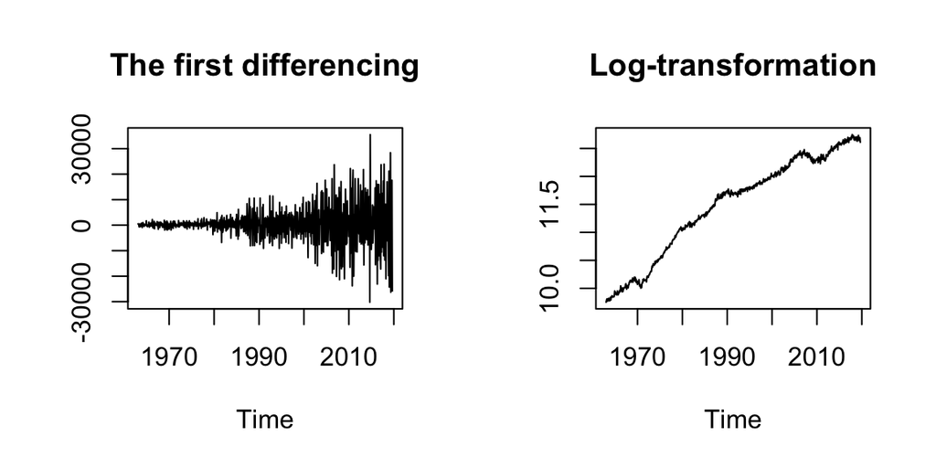

```r
par(mfrow=c(1,2))
plot(diff(med.home.ts), type='l',main='The first differencing',ylab='')
plot(log(med.home.ts), type='l',main='Log-transformation',ylab='')
```

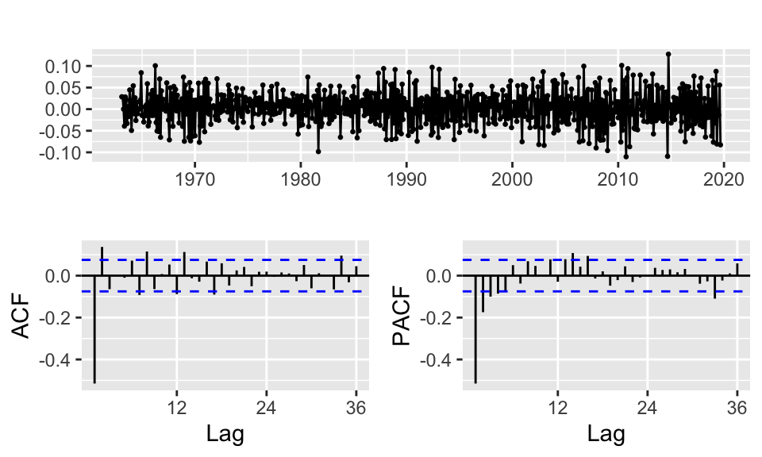

```r
ts_2 <- diff(log(med.home.ts))
ggtsdisplay(diff(log(med.home.ts)))
```

```r
eacf(ts_2)
```

```
## AR/MA
##   0 1 2 3 4 5 6 7 8 9 10 11 12 13
## 0 x x o o o o x x o o o  x  x  o
## 1 x x o o o o o x o o o  o  x  o
## 2 x x o o o o o o o o o  o  x  o
## 3 x o o x o o o o o o o  o  o  x
## 4 x o x x x o o o o o o  o  o  o
## 5 x o x x o o o x o o o  o  o  o
## 6 x o o x x o o o o o o  o  o  o
## 7 x x x x o o o o o o o  o  o  o
```

Both ACF and PACF do not have a clear cut-off, and the EACF plot does not provide which orders we should pick, so we need to create a function to search for the lowest AIC for ARIMA(p,1,q) with p is from 0 to 7 and q from 0 to 13. Here is the result:

```r
aic <- matrix(rep(NA,112),ncol=14)

for (i in 0:7) {
  for (j in 0:13) {
    aic[i+1,j+1] <- arima(ts_2, order=c(i,0,j))$aic
  }
}
colnames(aic) <- seq(0,13)
rownames(aic) <- seq(0,7)

round(aic,0) %>%
  kbl() %>%
  kable_styling(font_size = 10) %>%
  row_spec(1)
```

|  | 0 | 1 | 2 | 3 | 4 | 5 | 6 | 7 | 8 | 9 | 10 | 11 | 12 | 13 |
| --- | --- | --- | --- | --- | --- | --- | --- | --- | --- | --- | --- | --- | --- | --- |
| 0 | -2501 | -2733 | -2739 | -2740 | -2739 | -2740 | -2740 | -2738 | -2744 | -2742 | -2743 | -2743 | -2741 | -2748 |
| 1 | -2710 | -2740 | -2740 | -2738 | -2751 | -2749 | -2740 | -2738 | -2743 | -2741 | -2745 | -2742 | -2740 | -2747 |
| 2 | -2730 | -2740 | -2738 | -2738 | -2736 | -2747 | -2746 | -2745 | -2745 | -2744 | -2747 | -2745 | -2743 | -2746 |
| 3 | -2735 | -2738 | -2750 | -2737 | -2736 | -2746 | -2758 | -2754 | -2753 | -2751 | -2749 | -2747 | -2745 | -2744 |
| 4 | -2738 | -2738 | -2738 | -2736 | -2745 | -2744 | -2754 | -2752 | -2751 | -2749 | -2747 | -2745 | -2752 | -2746 |
| 5 | -2740 | -2741 | -2744 | -2746 | -2753 | -2754 | -2752 | -2751 | -2751 | -2750 | -2749 | -2747 | -2745 | -2744 |
| 6 | -2740 | -2739 | -2744 | -2742 | -2754 | -2752 | -2751 | -2749 | -2750 | -2748 | -2747 | -2745 | -2743 | -2752 |
| 7 | -2739 | -2736 | -2742 | -2745 | -2752 | -2750 | -2750 | -2749 | -2747 | -2745 | -2744 | -2742 | -2740 | -2747 |

```r
pos <- which(aic == min(aic), arr.ind = TRUE)
```

```r
model_2 <- arima(ts_2, order=c(3,0,6))
coef(model_2)
```

```
##          ar1          ar2          ar3          ma1          ma2          ma3
## -0.800240369  0.661133478  0.852184904  0.161062693 -1.055581245 -0.434088506
##          ma4          ma5          ma6    intercept
##  0.420262780 -0.032210441  0.149973107  0.004150235
```

#### Residual analysis for ARIMA(3,1,6) of log-transformed data

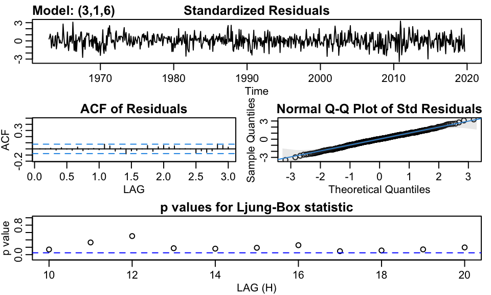

```r
sarima(log(med.home.ts), 3,1,6)
```

**The ARIMA(3,1,6) model is**:
$$\begin{align*}
W_t &= 0.0042 + -0.8 \times W_{t-1} + 0.66 \times W_{t-2} + 0.85 \times W_{t-3} + e_t + \\
& 0.16 \times e_{t-1} -1.05 \times e_{t-2} -0.43 \times e_{t-3} + 0.42 \times e_{t-4} - 0.03 \times e_{t-5} + 0.15 \times e_{t-6}
\end{align*}$$

where $W_t = log{Y_t} - log{Y_{t-1}}$

### Obtain forecasts and 95% prediction intervals for the forecasted median home values for the next 6 months: October 2019, November 2019, December 2019, January 2020, February 2020, and March 2020.

- Forecasted median home values:

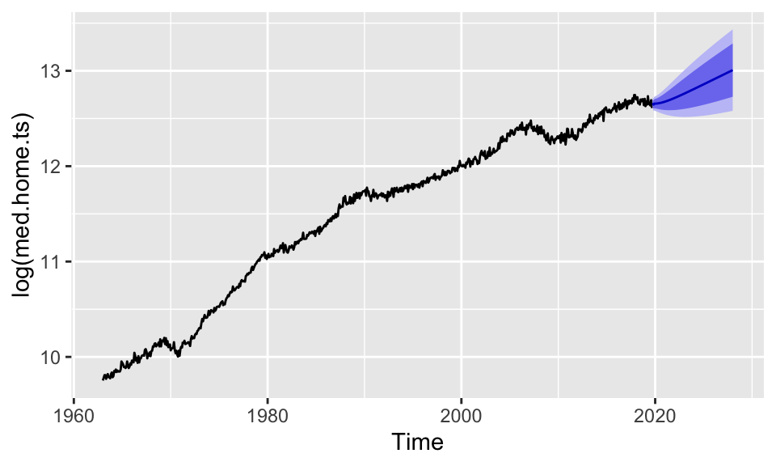

```r
autoplot(forecast(Arima(log(med.home.ts), order=c(3,1,6),include.mean = FALSE, include.drift = FALSE, include.constant =TRUE),h=100),main=NULL)
```

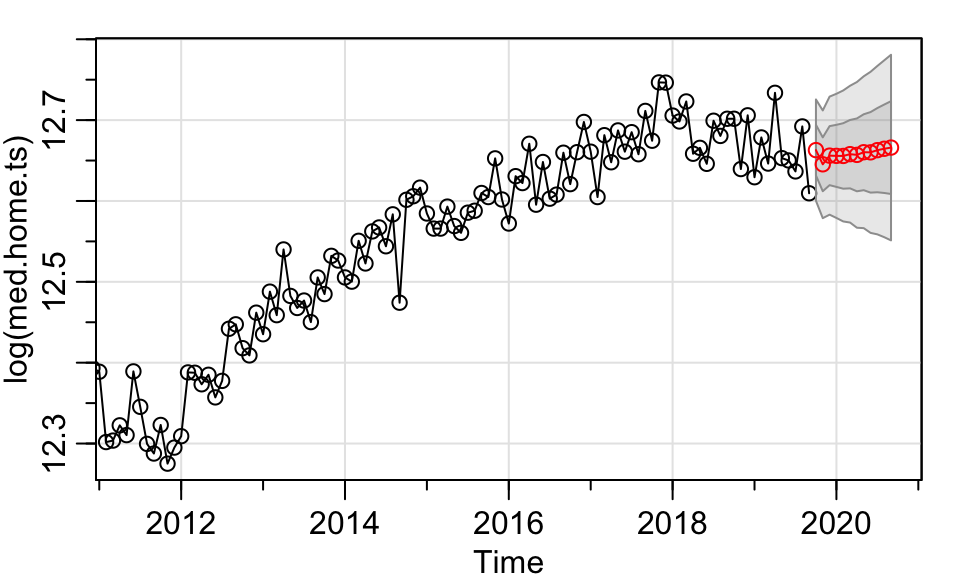

```r
exp(sarima.for(log(med.home.ts), 12, 3, 1, 6)$pred)
```

Using predict() function, we have the predicted values of the next 6 months: October 2019, November 2019, December 2019, January 2020, February 2020, and March 2020 are:

```r
round(exp(sarima.for(log(med.home.ts), 6, 3, 1, 6)$pred),0)
```

```
##         Jan    Feb    Mar Apr May Jun Jul Aug Sep    Oct    Nov    Dec
## 2019                                              315812 310315 313659
## 2020 313573 313541 314237
```

The 95% confident interval for prediction at time $t + l$ are $\hat{Y_t}(l) \pm Z_{0.25} \times se_t(l)$ or  
$\hat{Y_t}(l) \pm 1.96 \times se_t(l)$, with standard errors for 6 predictions are:

```r
round(exp(sarima.for(log(med.home.ts), 6, 3, 1, 6)$se),3)
```

```
##        Jan   Feb   Mar Apr May Jun Jul Aug Sep   Oct   Nov   Dec
## 2019                                           1.032 1.034 1.037
## 2020 1.039 1.041 1.043
```

```r
LB <- exp(sarima.for(log(med.home.ts), 6, 3, 1, 6)$pred) -
  1.96 * exp(sarima.for(log(med.home.ts), 6, 3, 1, 6)$se)
```

```r
UB <- exp(sarima.for(log(med.home.ts), 6, 3, 1, 6)$pred) +
  1.96 * exp(sarima.for(log(med.home.ts), 6, 3, 1, 6)$se)
```

Therefore, the 95% confident intervals for predictions of the next 6 months are [315809.8, 315813.8], [310313.3, 310317.4], [313657.3, 313661.3], [313570.9, 313574.9], [313538.6, 313542.7], and [314234.6, 314238.7]

### Based on the observed data and your model, find the approximate probability that the median home price in October 2019 will be more than $300,000.

The median home price data has 681 time points, hence let the median home price in October 2019 be $Y_{682}$. The approximate probability that the median home price in October 2019 will be more than $300,000 is:

$$\begin{align*}
P(Y_{682} > 300000) &= 1 - P(log{Y_{682}} \le log{300000}) \\
&= 1 - P(\frac{log{Y_{682}} - log{\hat{Y}_{682}}}{\sigma_{682}} \le \frac{log{300000} - log{\hat{Y}_{682}}}{\sigma_{682}}) \\
&= 1 - P(Z \le \frac{log{300000} - 12.6629}{0.0313}) \\
&= 1 - P(Z \le -1.6392) \\
&\approx 1 - 0.05050 \\
&=0.9495 \text{ or } 94.95\%
\end{align*}$$